# Independent Week 14

Christine Kandeo

2/5/2022

# Specific Data Analytics Question

Exploring, reducing the recent Carefour Marketing data using Principal Component Analysis and selecting the best features.

# Metrics for Success

Accurately determining the Principal Component’s explaining most of the variability in the data and selecting the best features

# Understanding the Context

Carrefour Kenya are currently undertaking a project that will inform the marketing department on the most relevant marketing strategies that will result in the highest number of sales. This project aims to explore a recent marketing dataset by performing various unsupervised learning techniques and providing insights.

# Experimental Design.

1.Data Preparation

- Loading the dataset
- Data Uniformity
- Checking for Missing/Duplicate Values

2.Dimensionality Reduction

- Principal Component Analysis

3.Feature Selection

- Wrapper Method
- Filter Method
4. Conclusions and Recommendations

# Data Relevance

Invoice id - Computer generated sales slip invoice identification number

Branch - Branch of the Supermarket (A, B and C)

Customer type - Type of customers, recorded by Members for customers using member card and Normal for without member card

Gender - Male or Female

Product line - General item categorization groups: Electronic accessories, Fashion accessories, Food and beverages, Health and beauty, Home and lifestyle, Sports and travel

Unit price - Price of each product

Quantity - Number of products purchased by customer

Tax - 5% tax fee for customer buying

Date - Date of purchase (Record available from January 2019 to March 2019)

Time - Purchase time

Payment - Payment used by customer for purchase (3 methods are available – Cash, Credit card and Ewallet)

COGS - Cost of goods sold

Gross margin percentage - Gross margin percentage

Gross income - Gross income

Rating - Customer stratification rating on their overall shopping experience (On a scale of 1 to 10)

Total - Total price including tax.

# 1. Data Preparation

Loading Libraries

```r
#Loading the relevant libraries:
library(stats)
library(devtools)
```

```r
library(ggbiplot)
library(caret)
library(GGally)
#For data manipulation:
library(dplyr)
#For visualization:
library(ggcorrplot)
library(ggplot2)

#For Feature selection:
library(clustvarsel)
library(mclust)
library(corrplot)
```

Loading the Dataset

```r
#Importing the data to the Global Environment:
Sales <- read.csv("http://bit.ly/CarreFourDataset", header = TRUE, sep = ",")

#Printing the first 4 rows of the dataframe
head(Sales, n=4)
```

```
##    Invoice.ID Branch Customer.type Gender           Product.line Unit.price
## 1 750-67-8428      A        Member Female      Health and beauty      74.69
## 2 226-31-3081      C        Normal Female Electronic accessories      15.28
## 3 631-41-3108      A        Normal   Male     Home and lifestyle      46.33
## 4 123-19-1176      A        Member   Male      Health and beauty      58.22
##   Quantity     Tax      Date  Time     Payment   cogs gross.margin.percentage
## 1        7 26.1415  1/5/2019 13:08     Ewallet 522.83                4.761905
## 2        5  3.8200  3/8/2019 10:29        Cash  76.40                4.761905
## 3        7 16.2155  3/3/2019 13:23 Credit card 324.31                4.761905
## 4        8 23.2880 1/27/2019 20:33     Ewallet 465.76                4.761905
##   gross.income Rating    Total
## 1      26.1415    9.1 548.9715
## 2       3.8200    9.6  80.2200
## 3      16.2155    7.4 340.5255
## 4      23.2880    8.4 489.0480
```

```r
#Checking the Number of Rows and Columns:
dim(Sales)
```

```
## [1] 1000   16
```

The Dataset is made up of 1,000 Rows and 16 Columns

Data Uniformity

```r
#Getting Information on the data types on each respective column:
sapply(Sales, class)
```

```
##              Invoice.ID                  Branch           Customer.type
##             "character"             "character"             "character"
##                  Gender            Product.line              Unit.price
##             "character"             "character"               "numeric"
##                Quantity                     Tax                    Date
##               "integer"               "numeric"             "character"
##                    Time                 Payment                    cogs
##             "character"             "character"               "numeric"
## gross.margin.percentage            gross.income                  Rating
##               "numeric"               "numeric"               "numeric"
##                   Total
##               "numeric"
```

```r
#Viewing the full information:
str(Sales)
```

```
## 'data.frame':    1000 obs. of  16 variables:
##  $ Invoice.ID             : chr  "750-67-8428" "226-31-3081" "631-41-3108" "123-19-1176" ...
##  $ Branch                 : chr  "A" "C" "A" "A" ...
##  $ Customer.type          : chr  "Member" "Normal" "Normal" "Member" ...
##  $ Gender                 : chr  "Female" "Female" "Male" "Male" ...
##  $ Product.line           : chr  "Health and beauty" "Electronic accessories" "Home and lifestyle" "Health and beauty" ...
##  $ Unit.price             : num  74.7 15.3 46.3 58.2 86.3 ...
##  $ Quantity               : int  7 5 7 8 7 7 6 10 2 3 ...
##  $ Tax                    : num  26.14 3.82 16.22 23.29 30.21 ...
##  $ Date                   : chr  "1/5/2019" "3/8/2019" "3/3/2019" "1/27/2019" ...
##  $ Time                   : chr  "13:08" "10:29" "13:23" "20:33" ...
##  $ Payment                : chr  "Ewallet" "Cash" "Credit card" "Ewallet" ...
##  $ cogs                   : num  522.8 76.4 324.3 465.8 604.2 ...
##  $ gross.margin.percentage: num  4.76 4.76 4.76 4.76 4.76 ...
##  $ gross.income           : num  26.14 3.82 16.22 23.29 30.21 ...
##  $ Rating                 : num  9.1 9.6 7.4 8.4 5.3 4.1 5.8 8 7.2 5.9 ...
##  $ Total                  : num  549 80.2 340.5 489 634.4 ...
```

Missing Values

```r
#Checking for null entries in each column:
colSums(is.na(Sales))
```

```
##              Invoice.ID                  Branch           Customer.type
##                       0                       0                       0
##                  Gender            Product.line              Unit.price
##                       0                       0                       0
##                Quantity                     Tax                    Date
##                       0                       0                       0
##                    Time                 Payment                    cogs
##                       0                       0                       0
## gross.margin.percentage            gross.income                  Rating
##                       0                       0                       0
##                   Total
##                       0
```

```r
#For the entire data set:
sum(is.na(Sales))
```

```
## [1] 0
```

The dataset has no missing values

Duplicate values

```r
#Checking for identical entries:
sum(duplicated(Sales))
```

```
## [1] 0
```

The dataset has no identical entries

# 2. Dimensionality Reduction

This process involves reducing the dimensions of the feature set.

Technique: Principal Component Analysis

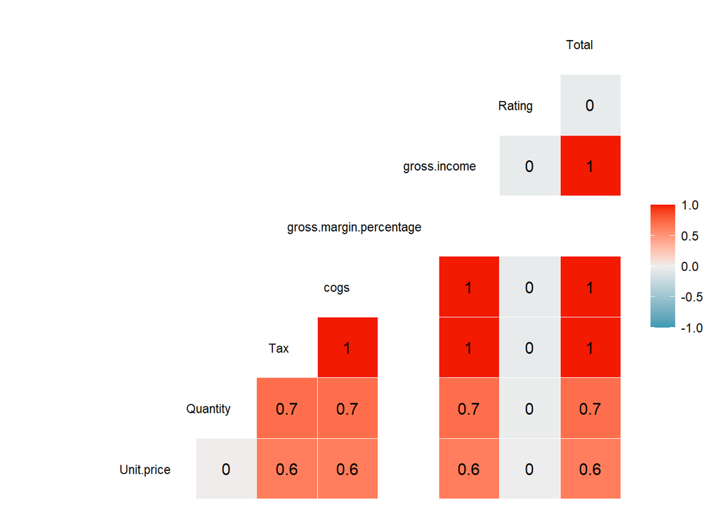

```r
#Checking PCA eligibility for linear dependency:
#Creating a dataframe Cr:
Dr<- Sales

#Visualizing the Plot
corr_map <- ggcorr(Dr[, 1:16], method=c("everything", "pearson"), label=TRUE, hjust = .90, size = 3, layout.exp = 2)
corr_map
```

The Plot above shows presence of Multicollinearity. PCA can effectively take advantage of Multicollinearity by combining the highly correlated variables into a set of uncorrelated variables.

```r
#Implementing PCA:
#Since PCA only accepts continuous variables, the categorical observations are ignored
#The Center argument is True so as to shift the variables to Zero centered
#Scale is true as the variables measurements are in different scales:

Pca <- prcomp(Sales[,c(6:8, 12, 14, 15)], center = TRUE, scale = TRUE)

#Displaying the information on Standard deviation and Loadings:
summary(Pca)
```

```
## Importance of components:
##                           PC1    PC2    PC3    PC4      PC5       PC6
## Standard deviation     1.9817 1.0002 0.9939 0.2909 2.51e-16 1.477e-16
## Proportion of Variance 0.6545 0.1667 0.1646 0.0141 0.00e+00 0.000e+00
## Cumulative Proportion  0.6545 0.8213 0.9859 1.0000 1.00e+00 1.000e+00
```

The First component explains 65% of the variability in the data set. The Second component explains 17% of total variability in the data set.

This indicates the first two components explain 82% of the Total variation in the data set.

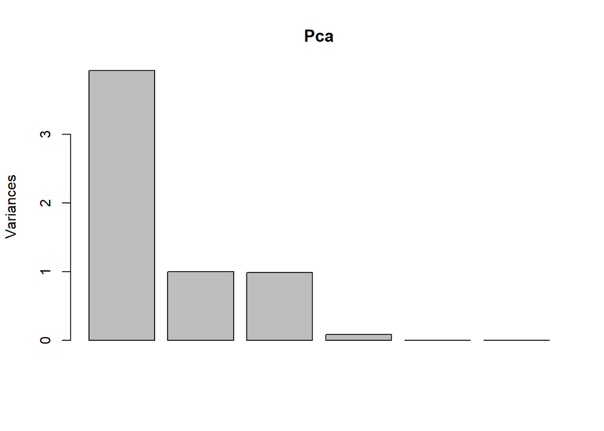

```r
#Plotting a scree plot of the Eigenvalues:
plot(Pca)
```

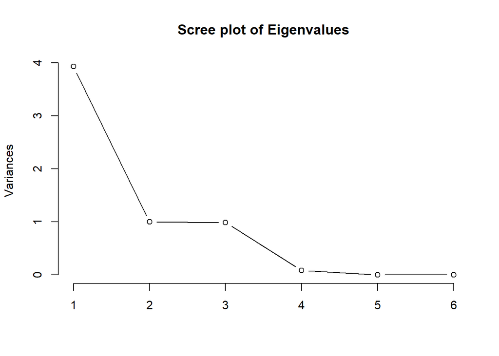

```r
screeplot(Pca, type = "line", main = "Scree plot of Eigenvalues")
```

The Scree Plot returns a plot of the variances (y-axis) associated with the PC’s (x-axis).

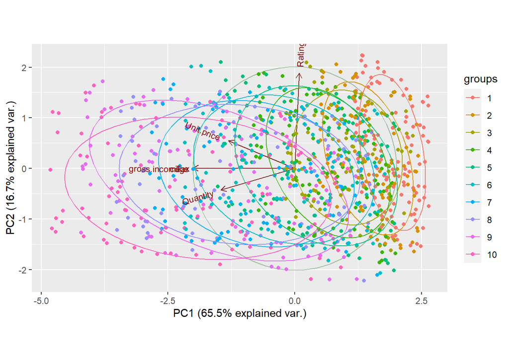

```r
#Making a biplot, which includes both the position of each sample in terms of PC1 and PC2 and showing how the initial variables map onto this:
ggbiplot(Pca, obs.scale = 0.8, var.scale = 1, groups = as.factor(Sales$Quantity), ellipse = TRUE, circle = TRUE)
```

The plot shows how samples relate to one another in the PCA based on the groups generated from quantity.

From the analysis, the first 2 Principal Components explain most of the variability in the data.

# 3. Feature Selection

This is the process of filtering irrelevant or redundant features from the dataset.

Having irrelevant features in the data can decrease the accuracy of the models and make a model learn based on irrelevant features.

Techniques applied are:

1. Wrapper Method

```r
#Using the clustvarsel function to find the optimal subset of variables in the dataset:
#out = clustvarsel(Sales[,c(6:8, 12, 14, 15)])
#out
```

2. Filter Method

```r
#Using the findcorrelation function to create a subset of variables:
#Creating a dataframe Core:
Core <- subset(Sales, select = -c(Date, Time, Invoice.ID, Customer.type, Branch, Gender, Product.line, Payment, gross.margin.percentage, Total))


#Calculate correlation matrix:
correlationMatrix <- cor(Core)

#Finding attributes that are highly corrected (ideally >0.75):
highlyCorrelated <- findCorrelation(correlationMatrix, cutoff=0.75)

#Printing indexes of highly correlated attributes:
names(Core[,highlyCorrelated])
```

```
## [1] "Tax"  "cogs"
```

Tax and Cogs are the highly correlated features. They have a perfect positive correlation of 1.

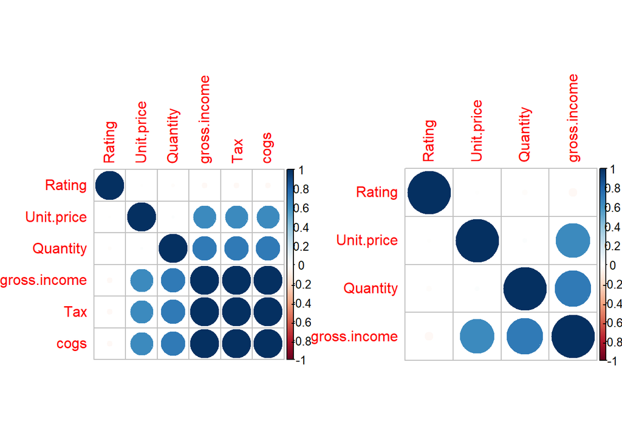

```r
#Removing the Redundant Features:
Core2 <- Core[-highlyCorrelated]

#Visualizing the representation:
par(mfrow = c(1, 2))
corrplot(correlationMatrix, order = "hclust")
corrplot(cor(Core2), order = "hclust")
```

After removing redundant variables, the best Features are Rating, Unit Price, Quantity and Gross Income.

# 4. Conclusions and Recommendations